# The Racial Gap in Employment and Layoffs during COVID-19 in the United States: A Visualization

Converted from PDF `Dias-RacialEmploymentLayoffGap-2021-Socius.pdf` · 3 pages · anchors: page `#pN`, block `#pN-bK`

Page 1

[figure not shown]

**text found inside the figure**

https://doi.org/10.1177/2378023120988397

Socius: Sociological Research for a Dynamic World Volume 7: 1–3 © The Author(s) 2021 Article reuse guidelines: sagepub.com/journals-permissions DOI: 10.1177/2378023120988397 srd.sagepub.com

Creative Commons Non Commercial CC BY-NC: This article is distributed under the terms of the Creative Commons Attribution- NonCommercial 4.0 License (https://creativecommons.org/licenses/by-nc/4.0/) which permits non-commercial use, reproduction and distribution of the work without further permission provided the original work is attributed as specified on the SAGE and Open Access pages (https://us.sagepub.com/en-us/nam/open-access-at-sage).

#### **Data Visualization**

This visualization illustrates the effects of the coronavirus disease 2019 (COVID-19) pandemic on the racial gap in employment in the United States, by focusing on two key measurements: the white-nonwhite gap in employment as share of the labor force and the probability of layoffs during the post-outbreak period. The data are from the January to August 2020 samples of the Current Population Survey (Flood et al. 2020).

by 62 percent (Figure 1B). Although the employment rate continued to rise, as the economy slowly recovered, the white-nonwhite gap in employment remained higher in August 2020 than in pre-COVID-19 months for all racial groups, except between white and Asian women.

Regression results for the male samples are shown in Figure 1C. The probability of being laid off during the

1Tufts University, Medford, MA, USA

**Corresponding Author:** Felipe A. Dias, Tufts University, Eaton Hall 115, Medford, MA 02155, USA Email: felipe.dias@tufts.edu

## **The Racial Gap in Employment and Layoffs during COVID-19 in the United States: A Visualization**

#### **Felipe A. Dias<sup>1</sup>**

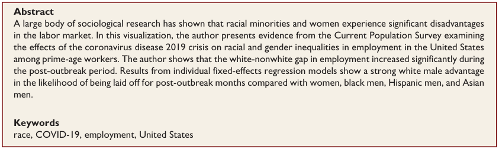

**text found inside the figure**

**Abstract** A large body of sociological research has shown that racial minorities and women experience significant disadvantages in the labor market. In this visualization, the author presents evidence from the Current Population Survey examining the effects of the coronavirus disease 2019 crisis on racial and gender inequalities in employment in the United States among prime-age workers. The author shows that the white-nonwhite gap in employment increased significantly during the post-outbreak period. Results from individual fixed-effects regression models show a strong white male advantage in the likelihood of being laid off for post-outbreak months compared with women, black men, Hispanic men, and Asian men.

**Keywords** race, COVID-19, employment, United States

1Before the COVID-19 outbreak, Hispanic men and Asian men had higher employment rates than white men.

Page 2

2 *Socius: Sociological Research for a Dynamic World *

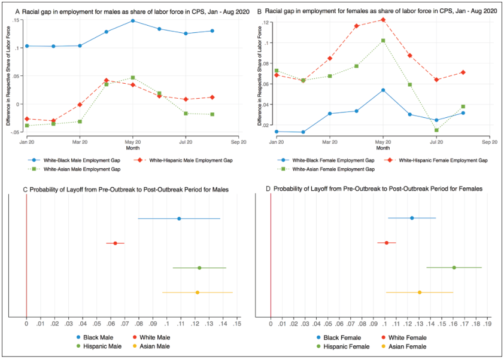

post-outbreak months increases by 10.9 percent for black men, 12.3 percent for Hispanic men, and 12.2 percent for Asian men. White men face an increase in the probability of being laid off of 6.3 percent, which is substantially smaller than the increase in the probability of being laid off for other racial groups. In the post-outbreak period, black men are 73 percent more likely to be laid off than white men, Hispanic men are 95.2 percent more likely to be laid off than white men, and Asian men are 93.7 percent more likely to be laid off than white men.

Figure 1D shows the results for the female samples. White women, black women, and Asian women are, respectively, 10.2 percent, 12.4 percent, and 13.1 percent more likely to be

laid off in the post-outbreak period. Hispanic women face the largest increase in the probability of being laid off compared with the other groups, at 16.1 percent. Black women and Asian women are, respectively, 21.6 percent and 28.4 percent more likely to be laid off than white women. Hispanic women are 57.8 percent more likely to be laid off compared with white women.

Possible explanations for the racial and gendered gaps in layoffs in the post-outbreak period include direct discrimination by employers (Quillian et al. 2017), who tend to place racialized minorities and women in positions of lower occupational status and more precarity, organizational features (e.g., biased formalization and accountability) (Kalev 2004),

**Figure 1.** (A and B) Racial gaps in employment. (C and D) Probability of being laid off in the post-outbreak period compared with the pre-outbreak period. *Source:* All data are from the Current Population Survey (CPS) from the U.S. Census Bureau and the U.S. Bureau of Labor Statistics, which was accessed through the Integrated Public Use Microdata Series (Flood et al. 2020). *Note:* In Figures 1A and 1B, the employment rate measurement is based on the employment-population ratio for prime-age workers (25–64 years old) from January through August 2020. Figures 1C and 1D show the coefficient estimates for the dependent variable, which is an indicator for being unemployed because of a layoff. The status of being unemployed because of a layoff is regressed on an indicator variable for the post–coronavirus disease 2019 time period (pre-outbreak period = 0, post-outbreak period = 1). The post-outbreak period refers to the April and May 2020 CPS rounds. The individual fixed-effect regression is estimated separately for white men, white women, black men, black women, Hispanic men, Hispanic women, Asian men, and Asian women. The full regression estimates for all race and gender groups are shown in Table 1S in the Online Supplement. All regressions include controls for age, education, and individual fixed effects.

Page 3

*Dias* 3

and processes of social closure that may lead to lower status within organizations (Tomaskovic-Devey and Avent-Holt 2019).

#### **ORCID iD**

Felipe A. Dias https://orcid.org/0000-0001-7007-4900

#### **Supplemental Material**

Supplemental material for this article is available online.

#### **References**

Flood, Sarah, Miriam King, Renae Rodgers, Steven Ruggles, and J.

Robert Warren. 2020. “Integrated Public Use Microdata Series, Current Population Survey: Version 7.0.” Minneapolis, MN: IPUMS. Retrieved January 5, 2021. https://ipums.org/projects/ ipums-cps/d030.v7.0.

Kalev, Alexandra. 2004. “How You Downsize Is Who You

Downsize: Biased Formalization, Accountability, and Mana gerial Diversity.” *American Sociological Review* 79(1):109–35. Quillian, Lincoln, Devah Pager, Ole Hexel, and Arnfinn H.

Midtbøen. 2017. “Meta-analysis of Field Experiments Shows No Change in Racial Discrimination in Hiring over Time.” *Proceedings of the National Academy of Sciences* 114(41): 10870–75. Tomaskovic-Devey, Donald, and Dustin Avent-Holt. 2019.

*Relational Inequalities: An Organizational Approach*. Oxford, UK: Oxford University Press.

#### **Author Biography**

**Felipe A. Dias** is an assistant professor of sociology at Tufts University. His research bridges insights from economic sociology, labor economics, race and ethnicity, gender, and immigration to understand the mechanisms associated with the reproduction of social inequality in the workplace.